# Analisis Exploratorio de Datos ENCSPA-2019- Proyecto Final Estadistica I

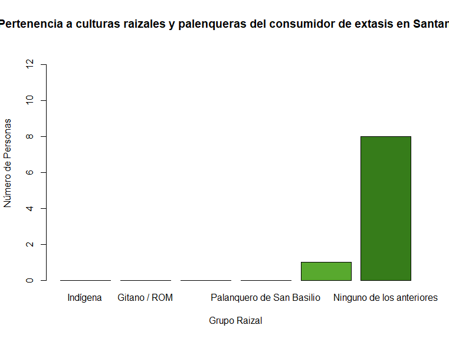

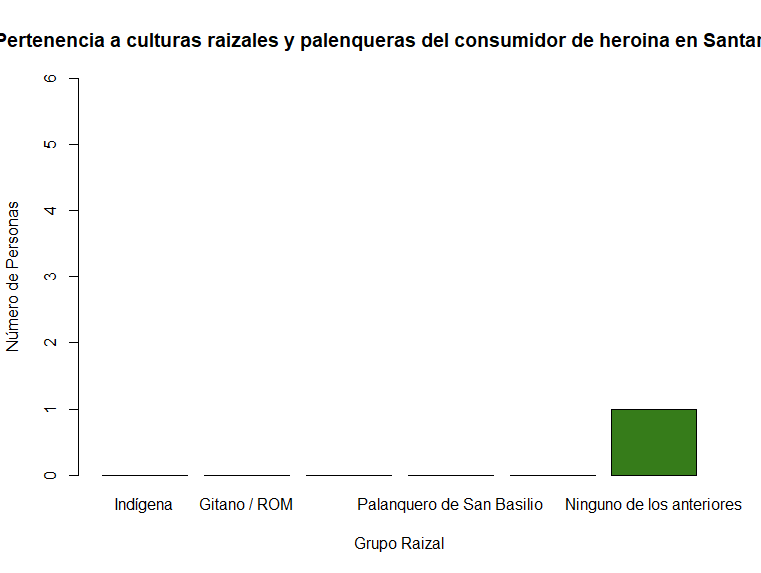

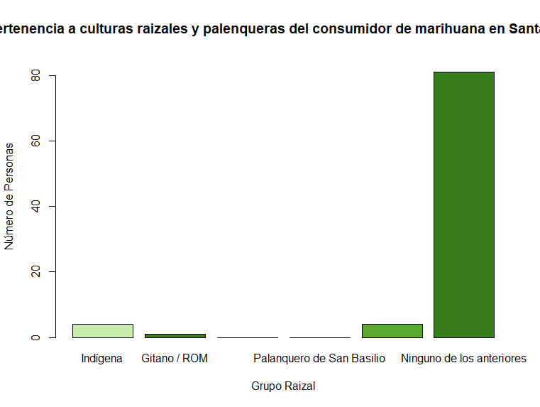

**6. Consumo y edad:**

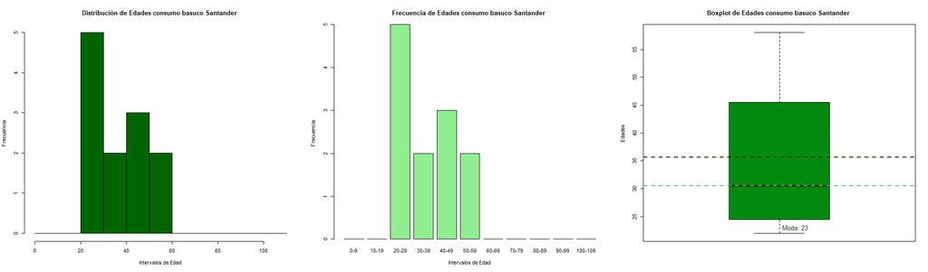

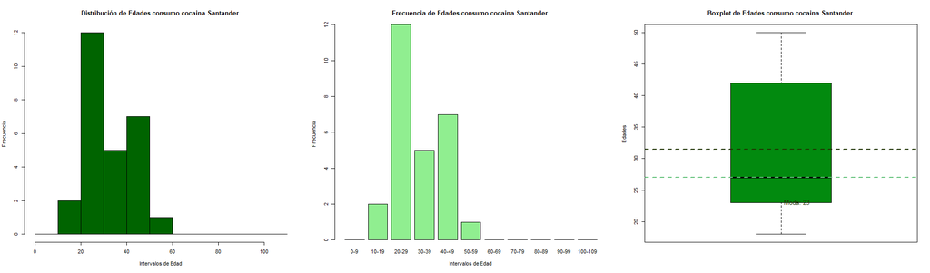

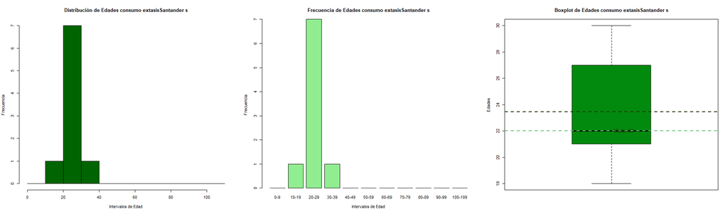

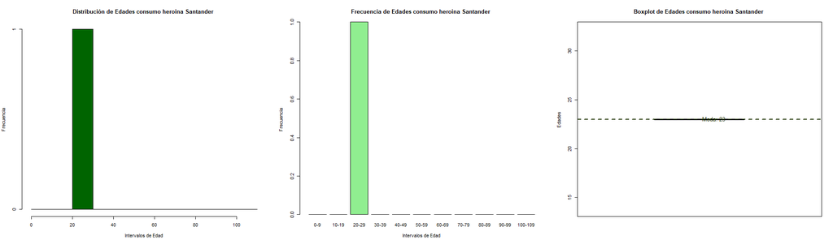

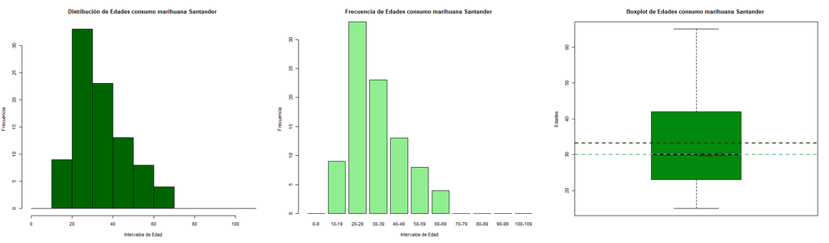

## Discusión

El estudio realizado en Santander revela hallazgos sobre el consumo de bazuco como lo es que la mayoría de los consumidores iniciaron el consumo de bazuco más de doce meses antes de la realización del estudio y un alto porcentaje dejó de consumir la sustancia en los meses siguientes al inicio. Se identificó consumo ligero de bazuco en poblaciones indígenas, negras y afrocolombianas. La mayoría de los consumidores reportan tener empleo, mientras que una minoría se dedica exclusivamente al ocio, los mismos se perciben con un estado de salud bueno, con pocos reportes negativos. Predomina el sexo masculino entre los consumidores y en términos de números, la edad promedio de los consumidores es de 35.67 años, con una mediana de 30.50 años. La edad con mayor frecuencia de consumo es de 23 años. La distribución de las edades presenta una desviación estándar de 12.95, una asimetría positiva (sesgo del 0.55) y una ligera leptocurtosis (curtosis de 0.55).

El perfil del consumidor de cocaína analizado revela que la mayoría de los consumidores contribuye económicamente al hogar, lo cual es coherente con el alto porcentaje que reporta tener empleo y predominio de un nivel educativo medio. Se auto perciben con un estado de salud que oscila entre regular y muy bueno; la gran mayoría se identifican como hombre, coincidiendo con el sexo al nacer, primando heterosexualidad, con escasa representación de minorías. La edad promedio es de 31.44 años, con una mediana de 27 y una moda de 23. La distribución de las edades presenta una desviación estándar de 10.39, una asimetría positiva (sesgo del 0.56) y una ligera leptocurtosis (curtosis de 0.56).

Si se perfila el consumidor de éxtasis, se encuentra que predomina el género femenino, la mayoría de los encuestados no reportó consumo de éxtasis en los últimos 12 meses, y afirmaron contribuir económicamente al hogar, siendo coherente con el hecho de que la principal actividad es trabajar. El nivel educativo se concentra principalmente en secundaria y técnica, reportan un estado de salud regular o bueno y la mayoría se identifica como mestiza o blanca, con una minoría que se identifica como afrocolombiana. Relacionado al género, puntea la identidad de género femenina, siendo predominante la heterosexualidad.La edad promedio es de 23.44 años, con una mediana y moda de 22 años. La distribución de las edades presenta una desviación estándar de 4, una ligera asimetría positiva y una ligera leptocurtosis. (sesgo y curtosis de 0.41).

En Santander solo se reportó un caso de consumo de heroína, cuyas características son: persona de 23 años, de sexo e identidad femenina, heterosexual, luego de la primera vez reporta que sigue consumiendo la sustancia, aporta económicamente al hogar, en dicho año su nivel de escolaridad alcanzado era secundaria, trabajaba y reportaba una condición de salud regular.

El consumo de marihuana destaca por su prevalencia en comparación con otras sustancias. El perfil del consumidor de marihuana se caracteriza por la dominancia en datos del sexo masculino, muchos reportaron no haber consumido marihuana en los últimos 12 meses y su contribución económica al hogar. Se observa una amplia variedad de niveles educativos, desde primaria hasta superior, incluyendo personas que no accedieron nunca a la educación. Se identifica una minoría perteneciente a grupos étnicos como indígenas, gitano/rom y afrocolombiano, y como principal actividad trabajar. Predomina la orientación heterosexual, aunque también se reportan casos de homosexualidad y bisexualidad, y si bien se reportan algunos casos con estado de salud malo o regular, la mayoría se percibe en buen estado de salud. La edad promedio es de 33.23 años, con una mediana y moda de 30 años. La distribución de las edades presenta una desviación estándar de 12.99, un sesgo y una curtosis de 0.8, lo que indica una distribución ligeramente asimétrica y más apuntada que una distribución normal.

## Conclusiones

**I.** Antioquia presenta una alta prevalencia en el consumo de sustancias psicoactivas.

**II.** El área metropolitana de Bucaramanga (incluyendo Floridablanca y Girón) concentra los índices más altos de consumo de sustancias psicoactivas en Santander.

**III.** El inicio del consumo de sustancias psicoactivas en Santander suele ocurrir más de un año antes de la realización de la encuesta.

**IV.** La mayoría de los encuestados reportaron no haber consumido sustancias psicoactivas en el último año.

**V.** El nivel educativo de los consumidores se concentra principalmente en la educación secundaria-media, con menor representación de niveles técnicos y profesionales.

**VII.** La mayoría de los consumidores se encuentran activos laboralmente, en ningún caso se observa incapacidad o pensión.

**VIII.** El consumo entre grupos minoritarios como indígenas, gitanos y afrodescendientes es bajo, y nulo en casos de palenqueros y raizales isleños.

**IX.** Los consumidores de bazuco y marihuana suelen reportar un peor estado de salud en comparación con otros grupos, donde no se reportan deficiencias en esta.

**X.** En todos los casos el consumidor solo se reconoce dos identidades de género, femenino y masculino.

**XI.** La orientación sexual predominante entre los consumidores es la heterosexual, la homosexualidad y la bisexualidad son menos frecuentes entre los consumidores, y otras no son reconocidas.

**XII.** El consumo de sustancias psicoactivas es predominantemente masculino, con algunas excepciones.

## Referencias

**Ministerio de Justicia y del Derecho.** (s/f). Gov.co. Recuperado el 10 de diciembre de 2024, de https://www.minjusticia.gov.co/programas-co/ODC/Paginas/Situaci%C3%B3n-consumo.aspx

**Encuesta Nacional de Consumo de Sustancias Psicoactivas en Población General - ENCSPA- 2019** - Colombia. (2020). [Data set].

ChatGPT. (s/f). Chatgpt.com. Recuperado el 10 de diciembre de 2024, de https://chatgpt.com/

Códigos de Colores HTML. (2015, septiembre 3). HTML Color Codes. https://htmlcolorcodes.com/es/  
Cohen, A. (2024, agosto 16). Metodología de un proyecto: ejemplo, cómo hacerla y qué incluye. Hubspot.es. https://blog.hubspot.es/marketing/metodologia-proyecto  
Gemini - chat to supercharge your ideas. (s/f). Gemini. Recuperado el 10 de diciembre de 2024, de https://gemini.google.com/app